# Practical Machine Learning - HW 1

Casey C

Sunday, August 24, 2014

## Read in dataset

```r
#Load the caret package and other relevant packages
library(caret)
library(lsr)
library(kernlab)
library(rattle)
library(evaluate)
library(formatR)

#Set working directory so I can reference the files I need:
setwd("C:/Users/ccorc244/Documents/04 - Classes/2014-08 - Machine Learning/Homework 1")


#Read in the CSV file
training_all <- read.csv(file="pml-training.csv",head=TRUE, sep=",")
```

## Cross validation with the initial dataset

The initial dataset consisted of 19,622 observations. To employ cross validation, I have gone with a 75%/25% split, allocating 75% of the training dataset provided to be my training set and then remaining 25% to be my testing dataset. The training set contained 14,718 observations and the testing dataset contained 4,904. I will employ several machine learning algorithms to determine the best predictor for the outcome variable and then run this algorithm on the test dataset that contains 25% of my original dataset. I will then apply this same algorithm to the assigned 20 data points not included in the training.csv file.

```r
#Create a training set and a testing set
inTrain <- createDataPartition(y=training_all$classe, p=0.75, list=FALSE)
training_new <- training_all[inTrain,]
testing_new <- training_all[-inTrain,]
```

## Cleaning the dataset

After examining this dataset, I started off by removing variables associated with skew, kurtosis, average, variance, etc. These columns were associated with rows that consisted of multiple measurements that were consolidated into one row. As the dataset was quite limited with respect to observations that contained these features, I opted to remove them from the model. This left 56 variables for analysis out of the original 160 variables.

```r
#Subset out columns related to kurtosis, skewness, min, max, stddev, avg, amplitude
#Also remove anything that is a factor or text, don't want to have to make dummy variables for these things
training_new <- training_new[,-grep("kurtosis|skewness|max_|min_|var_|stddev_|avg_|amplitude_|X|user_name|cvtd_timestamp|new_window", colnames(training_all))]
```

I checked to see if I should remove additional variables (specifically non-zero values) by applying the nearZeroVar function. The results of this function didn’t suggest any additional variables that should be removed beyond what was initially removed from the first pass.

```r
#Checking for near zero values - Didnt see anything crazy here
nsv <- nearZeroVar(training_new, saveMetrics=TRUE)
nsv
```

```
##                      freqRatio percentUnique zeroVar   nzv
## raw_timestamp_part_1     1.034       5.68691   FALSE FALSE
## raw_timestamp_part_2     1.000      88.72809   FALSE FALSE
## num_window               1.034       5.82280   FALSE FALSE
## roll_belt                1.114       7.84753   FALSE FALSE
## pitch_belt               1.032      11.53689   FALSE FALSE
## yaw_belt                 1.008      12.45414   FALSE FALSE
## total_accel_belt         1.065       0.19704   FALSE FALSE
## gyros_belt_x             1.053       0.86968   FALSE FALSE
## gyros_belt_y             1.156       0.46202   FALSE FALSE
## gyros_belt_z             1.062       1.12787   FALSE FALSE
## accel_belt_x             1.059       1.06672   FALSE FALSE
## accel_belt_y             1.141       0.94442   FALSE FALSE
## accel_belt_z             1.119       1.97038   FALSE FALSE
## magnet_belt_x            1.092       2.07229   FALSE FALSE
## magnet_belt_y            1.061       1.97717   FALSE FALSE
## magnet_belt_z            1.014       2.94877   FALSE FALSE
## roll_arm                53.312      16.68705   FALSE FALSE
## pitch_arm               88.276      19.37084   FALSE FALSE
## yaw_arm                 34.120      18.24976   FALSE FALSE
## total_accel_arm          1.010       0.44843   FALSE FALSE
## gyros_arm_x              1.010       4.28047   FALSE FALSE
## gyros_arm_y              1.481       2.51393   FALSE FALSE
## gyros_arm_z              1.181       1.61707   FALSE FALSE
## accel_arm_x              1.056       5.25887   FALSE FALSE
## accel_arm_y              1.113       3.58744   FALSE FALSE
## accel_arm_z              1.135       5.22489   FALSE FALSE
## magnet_arm_x             1.048       9.00258   FALSE FALSE
## magnet_arm_y             1.121       5.86357   FALSE FALSE
## magnet_arm_z             1.045       8.50659   FALSE FALSE
## roll_dumbbell            1.064      85.87444   FALSE FALSE
## pitch_dumbbell           2.360      83.42166   FALSE FALSE
## yaw_dumbbell             1.064      85.12026   FALSE FALSE
## total_accel_dumbbell     1.089       0.29216   FALSE FALSE
## gyros_dumbbell_x         1.022       1.63066   FALSE FALSE
## gyros_dumbbell_y         1.323       1.84128   FALSE FALSE
## gyros_dumbbell_z         1.017       1.33170   FALSE FALSE
## accel_dumbbell_x         1.008       2.79250   FALSE FALSE
## accel_dumbbell_y         1.036       3.07786   FALSE FALSE
## accel_dumbbell_z         1.229       2.73135   FALSE FALSE
## magnet_dumbbell_x        1.143       7.39231   FALSE FALSE
## magnet_dumbbell_y        1.206       5.63256   FALSE FALSE
## magnet_dumbbell_z        1.007       4.52507   FALSE FALSE
## roll_forearm            11.560      13.15396   FALSE FALSE
## pitch_forearm           59.429      18.12746   FALSE FALSE
## yaw_forearm             14.702      12.19595   FALSE FALSE
## total_accel_forearm      1.137       0.45522   FALSE FALSE
## gyros_forearm_x          1.025       1.92282   FALSE FALSE
## gyros_forearm_y          1.041       4.89197   FALSE FALSE
## gyros_forearm_z          1.115       1.93640   FALSE FALSE
## accel_forearm_x          1.056       5.34040   FALSE FALSE
## accel_forearm_y          1.038       6.66531   FALSE FALSE
## accel_forearm_z          1.009       3.82525   FALSE FALSE
## magnet_forearm_x         1.115       9.89265   FALSE FALSE
## magnet_forearm_y         1.194      12.52888   FALSE FALSE
## magnet_forearm_z         1.000      10.97975   FALSE FALSE
## classe                   1.469       0.03397   FALSE FALSE
```

Lastly, I looked for highly correlated variables in order to examine potential principal components for variable reduction. After examining the results of this method, I opted to forgo the principal component route in order to more easily interpret the results of whatever model I settled on.

```r
#Check correlation matrix
nums<-sapply(training_new, is.numeric)
training_num_only <- (training_new[,nums])
M<-abs(cor(training_num_only))
diag(M) <- 0
which(M > 0.8, arr.ind=T)
```

```
##                  row col
## yaw_belt           6   4
## total_accel_belt   7   4
## accel_belt_y      12   4
## accel_belt_z      13   4
## accel_belt_x      11   5
## magnet_belt_x     14   5
## roll_belt          4   6
## roll_belt          4   7
## accel_belt_y      12   7
## accel_belt_z      13   7
## pitch_belt         5  11
## magnet_belt_x     14  11
## roll_belt          4  12
## total_accel_belt   7  12
## accel_belt_z      13  12
## roll_belt          4  13
## total_accel_belt   7  13
## accel_belt_y      12  13
## pitch_belt         5  14
## accel_belt_x      11  14
## gyros_arm_y       22  21
## gyros_arm_x       21  22
## magnet_arm_x      27  24
## accel_arm_x       24  27
## magnet_arm_z      29  28
## magnet_arm_y      28  29
## accel_dumbbell_x  37  31
## accel_dumbbell_z  39  32
## gyros_dumbbell_z  36  34
## gyros_forearm_z   49  34
## gyros_dumbbell_x  34  36
## gyros_forearm_z   49  36
## pitch_dumbbell    31  37
## yaw_dumbbell      32  39
## gyros_forearm_z   49  48
## gyros_dumbbell_x  34  49
## gyros_dumbbell_z  36  49
## gyros_forearm_y   48  49
```

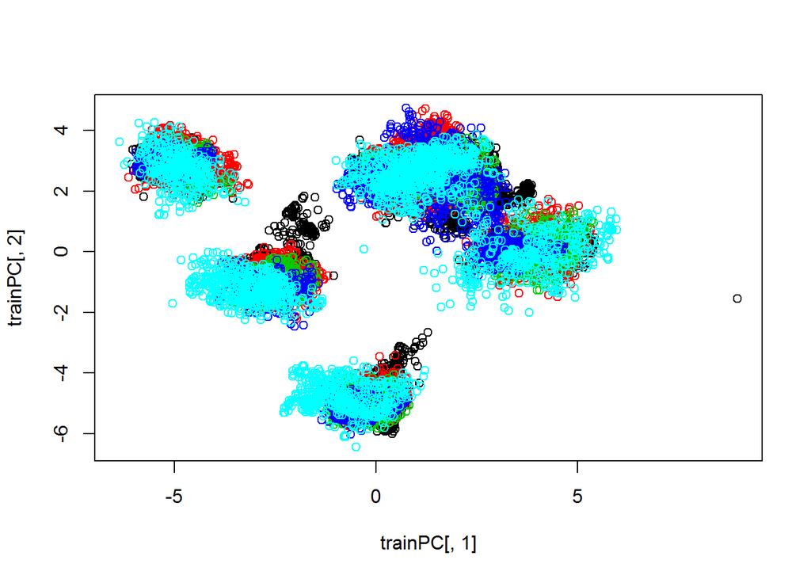

```r
#Create some principal components - Didn't really result in much
preProc <- preProcess(training_new[,-56], method="pca", pcaComp=2)
trainPC <- predict(preProc, training_new[,-56])
plot(trainPC[, 1], trainPC[, 2], col=training_new[,56])
```

## Applying machine learning algorithms

```r
#Decision tree
modFitDT <- train(classe ~ ., method="rpart", data=training_new)
print(modFitDT)
```

```
## CART
##
## 14718 samples
##    55 predictor
##     5 classes: 'A', 'B', 'C', 'D', 'E'
##
## No pre-processing
## Resampling: Bootstrapped (25 reps)
##
## Summary of sample sizes: 14718, 14718, 14718, 14718, 14718, 14718, ...
##
## Resampling results across tuning parameters:
##
##   cp    Accuracy  Kappa  Accuracy SD  Kappa SD
##   0.04  0.5       0.36   0.08         0.13
##   0.06  0.4       0.18   0.06         0.09
##   0.12  0.3       0.07   0.04         0.06
##
## Accuracy was used to select the optimal model using  the largest value.
## The final value used for the model was cp = 0.04011.
```

```r
confusionMatrix(predict(modFitDT, newdata=training_new), training_new$classe)
```

```
## Confusion Matrix and Statistics
##
##           Reference
## Prediction    A    B    C    D    E
##          A 3812 1169 1208 1061  379
##          B   61  971   76  436  360
##          C  302  708 1283  915  726
##          D    0    0    0    0    0
##          E   10    0    0    0 1241
##
## Overall Statistics
##
##                Accuracy : 0.496
##                  95% CI : (0.488, 0.505)
##     No Information Rate : 0.284
##     P-Value [Acc > NIR] : <2e-16
##
##                   Kappa : 0.342
##  Mcnemar's Test P-Value : NA
##
## Statistics by Class:
##
##                      Class: A Class: B Class: C Class: D Class: E
## Sensitivity             0.911    0.341   0.4998    0.000   0.4586
## Specificity             0.638    0.921   0.7818    1.000   0.9992
## Pos Pred Value          0.500    0.510   0.3261      NaN   0.9920
## Neg Pred Value          0.947    0.854   0.8809    0.836   0.8912
## Prevalence              0.284    0.194   0.1744    0.164   0.1839
## Detection Rate          0.259    0.066   0.0872    0.000   0.0843
## Detection Prevalence    0.518    0.129   0.2673    0.000   0.0850
## Balanced Accuracy       0.774    0.631   0.6408    0.500   0.7289
```

```r
#fancyRpartPlot(modFitDT$finalModel)
tableDT <- table(predict(modFitDT, newdata=training_new),training_new$classe)
ftable(tableDT)
```

```
##       A    B    C    D    E
##
## A  3812 1169 1208 1061  379
## B    61  971   76  436  360
## C   302  708 1283  915  726
## D     0    0    0    0    0
## E    10    0    0    0 1241
```

**Random Forest** Unfortunately this algorithm was too strenuous for my computer given the default parameters. I could have tried playing around with the options to try to get this method to work, but I decided to exhaust the other options first.

```r
#Random forest - Too strenuous for computer :( :(
#modFitRF <- train(classe ~ ., method="rf", data=training_new, prox=TRUE)
#modFitRF
```

```r
#Try linear discriminant analysis - 71% accuracy, meh
modFitLDA = train(classe ~ ., data=training_new, method="lda")
print(modFitLDA)
```

```
## Linear Discriminant Analysis
##
## 14718 samples
##    55 predictor
##     5 classes: 'A', 'B', 'C', 'D', 'E'
##
## No pre-processing
## Resampling: Bootstrapped (25 reps)
##
## Summary of sample sizes: 14718, 14718, 14718, 14718, 14718, 14718, ...
##
## Resampling results
##
##   Accuracy  Kappa  Accuracy SD  Kappa SD
##   0.7       0.6    0.005        0.006
##
##
```

```r
confusionMatrix(predict(modFitLDA, newdata=training_new), training_new$classe)
```

```
## Confusion Matrix and Statistics
##
##           Reference
## Prediction    A    B    C    D    E
##          A 3517  389  253  129  126
##          B  126 1876  224   98  375
##          C  230  360 1736  293  236
##          D  303  101  286 1817  259
##          E    9  122   68   75 1710
##
## Overall Statistics
##
##                Accuracy : 0.724
##                  95% CI : (0.717, 0.731)
##     No Information Rate : 0.284
##     P-Value [Acc > NIR] : <2e-16
##
##                   Kappa : 0.651
##  Mcnemar's Test P-Value : <2e-16
##
## Statistics by Class:
##
##                      Class: A Class: B Class: C Class: D Class: E
## Sensitivity             0.840    0.659    0.676    0.753    0.632
## Specificity             0.915    0.931    0.908    0.923    0.977
## Pos Pred Value          0.797    0.695    0.608    0.657    0.862
## Neg Pred Value          0.935    0.919    0.930    0.950    0.922
## Prevalence              0.284    0.194    0.174    0.164    0.184
## Detection Rate          0.239    0.127    0.118    0.123    0.116
## Detection Prevalence    0.300    0.183    0.194    0.188    0.135
## Balanced Accuracy       0.878    0.795    0.792    0.838    0.805
```

```r
table(predict(modFitLDA, newdata=training_new),training_new$classe)
```

```
##
##        A    B    C    D    E
##   A 3517  389  253  129  126
##   B  126 1876  224   98  375
##   C  230  360 1736  293  236
##   D  303  101  286 1817  259
##   E    9  122   68   75 1710
```

**Boosting with Decision Trees** This algorithm resulted in the best classification results as it takes repeated applications of weaker decision tree predictions to create a stronger prediction. Employing this method led to an in-sample accuracy estimate of >0.99. As this method was promising with regards to the in-sample data, I was ready to apply the model predictors to the test dataset I had created at the beginning of the analysis.

```r
#Boosting w/decision trees - Pretty good success!
modFitBO <- train(classe ~ ., method="gbm", data=training_new, verbose=FALSE)
options(digits=10)
print(modFitBO)
```

```
## Stochastic Gradient Boosting
##
## 14718 samples
##    55 predictor
##     5 classes: 'A', 'B', 'C', 'D', 'E'
##
## No pre-processing
## Resampling: Bootstrapped (25 reps)
##
## Summary of sample sizes: 14718, 14718, 14718, 14718, 14718, 14718, ...
##
## Resampling results across tuning parameters:
##
##   interaction.depth  n.trees  Accuracy  Kappa  Accuracy SD  Kappa SD
##   1                   50      0.806     0.754  0.00893      0.01129
##   1                  100      0.884     0.854  0.00515      0.00645
##   1                  150      0.914     0.891  0.00524      0.00661
##   2                   50      0.932     0.914  0.00522      0.00658
##   2                  100      0.977     0.971  0.00339      0.00428
##   2                  150      0.990     0.988  0.00155      0.00195
##   3                   50      0.968     0.959  0.00310      0.00391
##   3                  100      0.992     0.990  0.00114      0.00144
##   3                  150      0.995     0.994  0.00092      0.00116
##
## Tuning parameter 'shrinkage' was held constant at a value of 0.1
## Accuracy was used to select the optimal model using  the largest value.
## The final values used for the model were n.trees = 150,
##  interaction.depth = 3 and shrinkage = 0.1.
```

I also took some time to understand what the largest drivers were for this analysis. The largest driver of classification here is the timestamp variable. This makes sense as the form classification of weight lifting (outcome variable) may degrade as a participant continuously lifts weights. Another variable which had a high influence on the classification was the roll belt measurement, which suggests that changes in this measurement impact the form of participants.

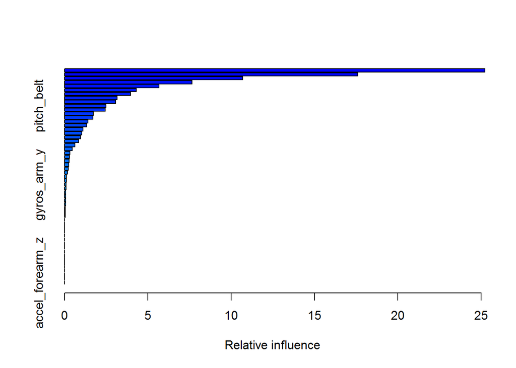

```
##                                       var        rel.inf
## raw_timestamp_part_1 raw_timestamp_part_1 25.23462702123
## roll_belt                       roll_belt 17.61655203701
## num_window                     num_window 10.70060082950
## pitch_forearm               pitch_forearm  7.66144266488
## magnet_dumbbell_z       magnet_dumbbell_z  5.66416760378
## roll_forearm                 roll_forearm  4.30820508030
## magnet_dumbbell_y       magnet_dumbbell_y  3.95760269062
## yaw_belt                         yaw_belt  3.15984529792
## magnet_belt_z               magnet_belt_z  3.07573209187
## pitch_belt                     pitch_belt  2.49255516717
## roll_dumbbell               roll_dumbbell  2.44381696939
## accel_forearm_x           accel_forearm_x  1.73769234374
## gyros_dumbbell_y         gyros_dumbbell_y  1.69856422829
## accel_dumbbell_z         accel_dumbbell_z  1.41791584872
## gyros_belt_z                 gyros_belt_z  1.34803623939
## accel_dumbbell_y         accel_dumbbell_y  1.10311164892
## magnet_dumbbell_x       magnet_dumbbell_x  1.04664452743
## yaw_arm                           yaw_arm  0.97325155692
## accel_dumbbell_x         accel_dumbbell_x  0.85564678370
## roll_arm                         roll_arm  0.63406865442
## accel_belt_z                 accel_belt_z  0.45719131996
## magnet_forearm_z         magnet_forearm_z  0.32636998992
## magnet_belt_x               magnet_belt_x  0.29769227352
## magnet_arm_y                 magnet_arm_y  0.26987820304
## gyros_belt_y                 gyros_belt_y  0.25920290264
## magnet_belt_y               magnet_belt_y  0.22185891694
## magnet_arm_z                 magnet_arm_z  0.18621681277
## pitch_dumbbell             pitch_dumbbell  0.12403694270
## gyros_dumbbell_x         gyros_dumbbell_x  0.11471947764
## gyros_arm_y                   gyros_arm_y  0.10267207352
## magnet_arm_x                 magnet_arm_x  0.09774687353
## yaw_dumbbell                 yaw_dumbbell  0.07111232929
## total_accel_dumbbell total_accel_dumbbell  0.07083477988
## magnet_forearm_y         magnet_forearm_y  0.06675866576
## accel_arm_x                   accel_arm_x  0.06060404038
## gyros_dumbbell_z         gyros_dumbbell_z  0.05076512768
## magnet_forearm_x         magnet_forearm_x  0.04812620766
## gyros_forearm_z           gyros_forearm_z  0.04413377799
## raw_timestamp_part_2 raw_timestamp_part_2  0.00000000000
## total_accel_belt         total_accel_belt  0.00000000000
## gyros_belt_x                 gyros_belt_x  0.00000000000
## accel_belt_x                 accel_belt_x  0.00000000000
## accel_belt_y                 accel_belt_y  0.00000000000
## pitch_arm                       pitch_arm  0.00000000000
## total_accel_arm           total_accel_arm  0.00000000000
## gyros_arm_x                   gyros_arm_x  0.00000000000
## gyros_arm_z                   gyros_arm_z  0.00000000000
## accel_arm_y                   accel_arm_y  0.00000000000
## accel_arm_z                   accel_arm_z  0.00000000000
## yaw_forearm                   yaw_forearm  0.00000000000
## total_accel_forearm   total_accel_forearm  0.00000000000
## gyros_forearm_x           gyros_forearm_x  0.00000000000
## gyros_forearm_y           gyros_forearm_y  0.00000000000
## accel_forearm_y           accel_forearm_y  0.00000000000
## accel_forearm_z           accel_forearm_z  0.00000000000
```

```r
summary(modFitBO)
```

```r
table(predict(modFitBO, newdata=training_new),training_new$classe)
```

```
##
##        A    B    C    D    E
##   A 4184    1    0    0    0
##   B    1 2846    3    0    0
##   C    0    1 2560    5    0
##   D    0    0    4 2401    1
##   E    0    0    0    6 2705
```

```r
#Calculate in sample error (though we get this from the output, I just wanted additional significant digits)
check_in_sample <- predict(modFitBO, newdata=training_new) == training_new$classe
in_sample_accuracy <- table(check_in_sample)["TRUE"]/length(check_in_sample)
in_sample_accuracy
```

```
##         TRUE
## 0.9985052317
```

## Estimating out of sample error

To understand the out of sample error, we’d want to look at the accuracy estimates on our test dataset (out of sample error) and compare it to the accuracy estimate on our training dataset (in-sample error). Wed expect the out of sample error to be larger than the in-sample error. To calculate the out of sample accuracy and kappa levels, I ran a confusion matrix on the predicted classifications based on my boosting decision tree model with the actual classifications from the testing dataset I had created.

[output not shown]

As you can see, the accuracy estimate is slightly lower for the out of sample error estimate which makes sense as this data was not included in developing the model. As a result, the out of sample accuracy and kappa rates are better estimates of the true out of sample error associated with this data as we have avoided over fitting our model as much as possible.

```r
#Check decision tree w/boosting results on my test dataset
table(predict(modFitBO, newdata=testing_new),testing_new$classe)
```

```
##
##        A    B    C    D    E
##   A 1393    4    0    0    0
##   B    2  941    0    0    0
##   C    0    4  854    6    0
##   D    0    0    1  790    0
##   E    0    0    0    8  901
```

```r
#Calculate the out of sample error based on this test dataset
check <- predict(modFitBO, newdata=testing_new) == testing_new$classe
out_sample_accuracy <- table(check)["TRUE"]/length(check)
out_sample_accuracy
```

```
##         TRUE
## 0.9949021207
```

```r
#Run a confusion matrix to get out of sample error
confusionMatrix(predict(modFitBO, newdata=testing_new), testing_new$classe)
```

```
## Confusion Matrix and Statistics
##
##           Reference
## Prediction    A    B    C    D    E
##          A 1393    4    0    0    0
##          B    2  941    0    0    0
##          C    0    4  854    6    0
##          D    0    0    1  790    0
##          E    0    0    0    8  901
##
## Overall Statistics
##
##                Accuracy : 0.9949021
##                  95% CI : (0.9924837, 0.9966983)
##     No Information Rate : 0.2844617
##     P-Value [Acc > NIR] : < 2.2204e-16
##
##                   Kappa : 0.9935514
##  Mcnemar's Test P-Value : NA
##
## Statistics by Class:
##
##                       Class: A  Class: B  Class: C  Class: D  Class: E
## Sensitivity          0.9985663 0.9915701 0.9988304 0.9825871 1.0000000
## Specificity          0.9988601 0.9994943 0.9975303 0.9997561 0.9980015
## Pos Pred Value       0.9971367 0.9978791 0.9884259 0.9987358 0.9911991
## Neg Pred Value       0.9994297 0.9979803 0.9997525 0.9965962 1.0000000
## Prevalence           0.2844617 0.1935155 0.1743475 0.1639478 0.1837276
## Detection Rate       0.2840538 0.1918842 0.1741436 0.1610930 0.1837276
## Detection Prevalence 0.2848695 0.1922920 0.1761827 0.1612969 0.1853589
## Balanced Accuracy    0.9987132 0.9955322 0.9981803 0.9911716 0.9990007
```

## Application of model parameters to the 20 observation test dataset

The resulting boosting decision tree model was applied to the 20 data points provided without the “classe” values present. This model was able to predict all 20 values accurately.

```r
#Read in the testing data set
#Let's see how great my model is in real life!
testing_all <- read.csv(file="pml-testing.csv",head=TRUE, sep=",")
new_predictions <- predict(modFitBO, newdata=testing_all)
new_predictions
```

```
##  [1] B A B A A E D B A A B C B A E E A B B B
## Levels: A B C D E
```

```r
#Save the predicted values to individual text files for upload
pml_write_files = function(x){
  n = length(x)
  for(i in 1:n){
    filename = paste0("problem_id_",i,".txt")
    write.table(x[i],file=filename,quote=FALSE,row.names=FALSE,col.names=FALSE)
  }
}
pml_write_files(new_predictions)
```